# Náhodná prechádzka

#### Definícia:

Nech časový rad $X_t$ je IID šum, t.j. rad nezávislých rovnako rozdelených náhodných veličín. Procesom náhodnej prechádzky, alebo skrátene náhodnou prechádzkou $S_t, \quad t=0,1,2,\dots$ nazývame ČR definovaný vzťahom:
$$S_0 = 0$$
$$S_t = X_1+X_2+\ldots+X_t, \quad t=1,2,\dots$$

#### Poznámka:

V prípade, že $X_t$ je binárny proces s $p=1/2$, hovoríme o jednoduchej symetrickej náhodnej prechádzke, pre $p\neq 1/2$ o jednoduchej nesymetrickej náhodnej prechádzke.

#### Úloha:

Vypočítajte základné charakteristiky náhodnej prechádzky.

#### Aplikácie náhodnej prechádzky

- populačná genetika - popis genetického driftu
- difúzia - v kvapalinách, v plynoch
- pohyb zvierat
- veľkosť webu - odhad
- neurológia - modelovanie šírenia vzruchov
- počas 2. svetovej vojny - modelovanie pohybu utečenca
- modelovanie zisku hráča hazardnej hry

#### Úloha:

Uvažujme proces daný rovnicami:
$$X_0 = 0$$
$$X_t = X_{t-1}+Z_t, \quad t=1,2,\dots,$$
kde $\{Z_t\}\sim \mathrm{IID} \sim \mathrm{N}(0, \sigma^2)$

1. Dokážte, že daný proces je náhodnou prechádzkou.
2. Aké má charakteristiky?
3. Vygenerujte aspoň 5 realizácií tohto procesu.

#### Generovanie náhodnej prechádzky

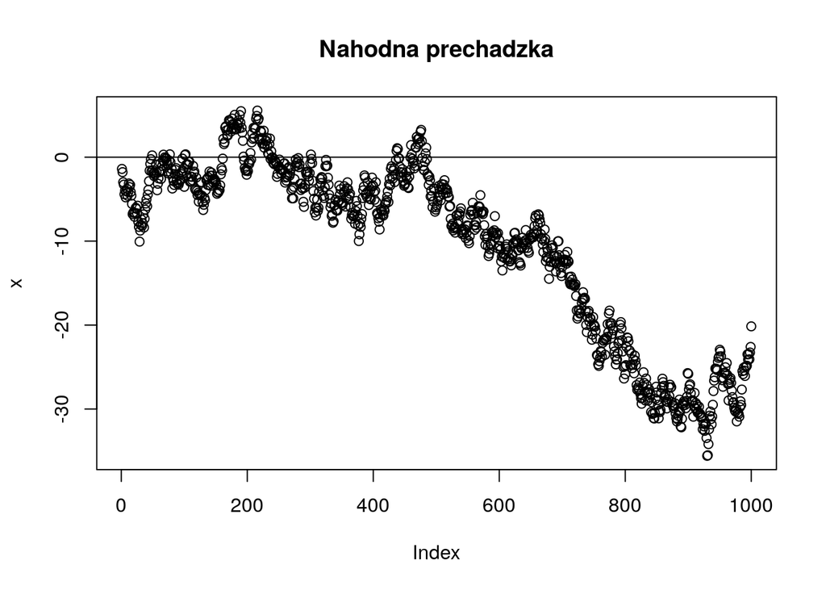

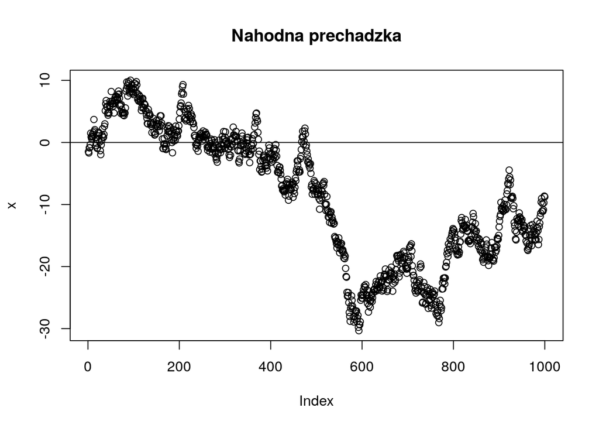

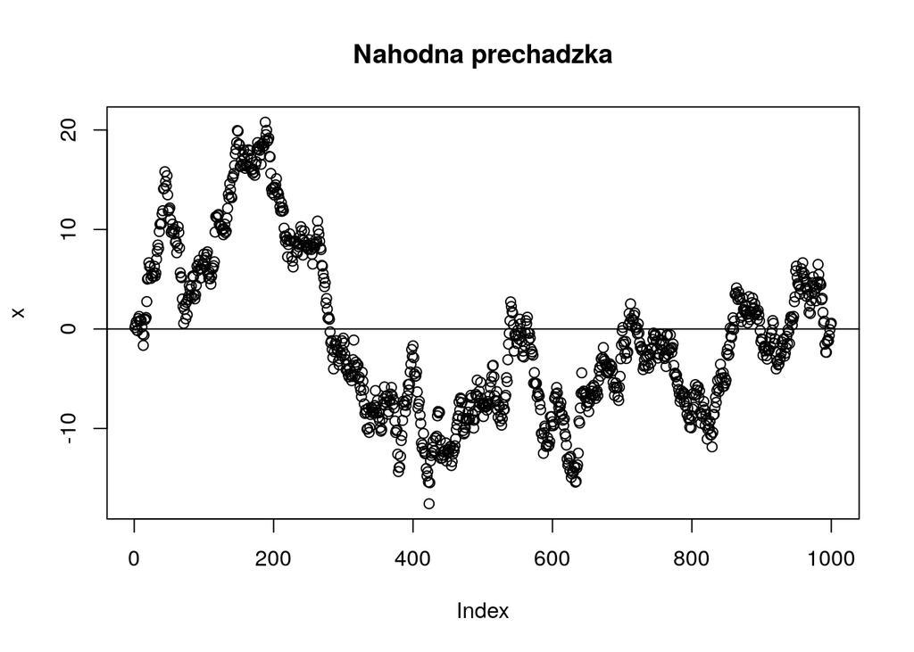

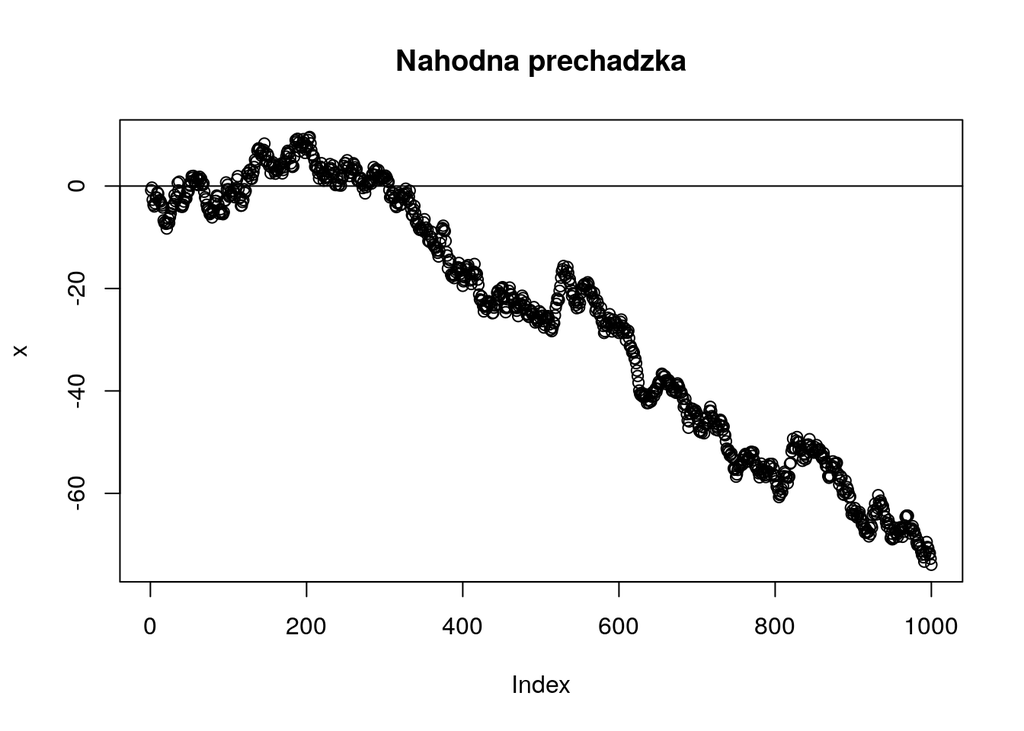

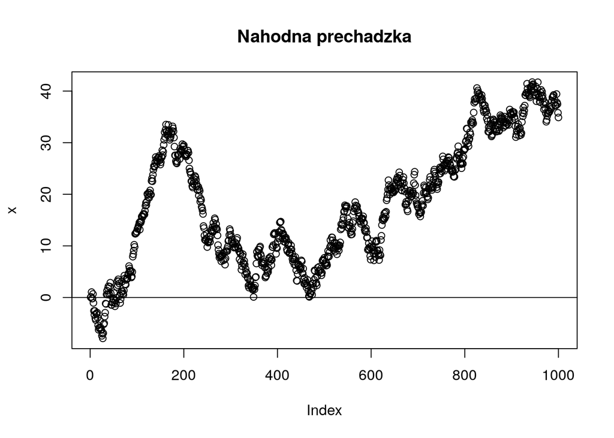

```r
n = 1000
for(i in 1:5){
  Z = rnorm(n,0,1)
  x = cumsum(Z)
  par(mfrow=c(1,1))
  plot(x, main='Nahodna prechadzka')
  abline(0,0)
}
```

#### Úloha:

Dokážte, že autoregresné rovnice pre AR(1) nemajú stacionárne riešenie pre $|\phi|= 1.$

#### Úloha:

Identifikujte o aký proces ide a určte, ktorý z procesov je kauzálny alebo invertibilný:

1. $X_t+1.8X_{t-1}+0.81X_{t-2}=Z_{t}, \quad Z_{t}\sim \mathrm{WN}$
2. $X_t+1.9X_{t-1}+0.88X_{t-2}=Z_{t}+0.2Z_{t-1}+0.7Z_{t-2}, \quad Z_{t}\sim \mathrm{WN}$